# Artificial Intelligence Lab - Lab 08

### Travelling on Vacations to Romania

**Name:** Mehr Ali  
**Semester:** 4th Semester BSCS

## Problem Statement

The map of Romania is represented as a graph, with cities as **nodes** and roads as **edges**. We are given a starting city and a goal city. We need to write two functions, one using **BFS** and one using **DFS**, to find a path between the starting city and the goal city.

- **G**: A NetworkX graph object representing the map of Romania
- **start**: The starting city
- **goal**: The goal city

The functions should return a **list of cities** from start to goal, or **None** if no path exists.

## Step 1: Import Libraries

```python
import networkx as nx
import matplotlib.pyplot as plt
```

## Step 2: Generate the Romania Graph

```python
G = nx.Graph()

G.add_edges_from([
    ('Arad', 'Zerind'),
    ('Arad', 'Sibiu'),
    ('Arad', 'Timisoara'),
    ('Zerind', 'Oradea'),
    ('Oradea', 'Sibiu'),
    ('Sibiu', 'Fagaras'),
    ('Sibiu', 'Rimnicu Vilcea'),
    ('Timisoara', 'Lugoj'),
    ('Lugoj', 'Mehadia'),
    ('Mehadia', 'Dobreta'),
    ('Dobreta', 'Craiova'),
    ('Craiova', 'Rimnicu Vilcea'),
    ('Craiova', 'Pitesti'),
    ('Rimnicu Vilcea', 'Pitesti'),
    ('Fagaras', 'Bucharest'),
    ('Pitesti', 'Bucharest'),
    ('Bucharest', 'Giurgiu'),
    ('Bucharest', 'Urziceni'),
    ('Urziceni', 'Hirsova'),
    ('Urziceni', 'Vaslui'),
    ('Hirsova', 'Eforie'),
    ('Vaslui', 'Iasi'),
    ('Iasi', 'Neamt')
])

print("Graph created!")
print("Cities:", G.number_of_nodes())
print("Roads :", G.number_of_edges())
```

```
Graph created!
Cities: 20
Roads : 23
```

## Step 3: Draw the Romania Map

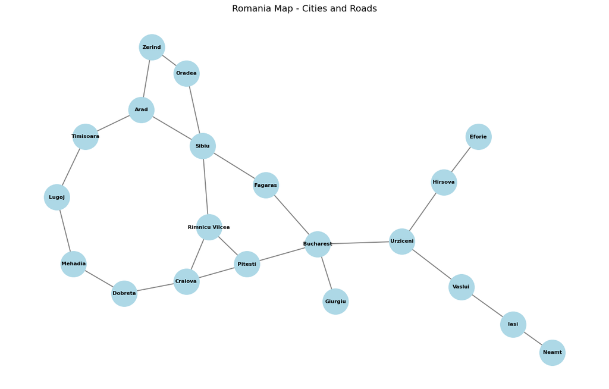

```python
plt.figure(figsize=(13, 8))
pos = nx.spring_layout(G, seed=42)
nx.draw(G, pos,
        with_labels=True,
        node_color='lightblue',
        node_size=1600,
        font_size=8,
        font_weight='bold',
        edge_color='gray',
        width=1.5)
plt.title('Romania Map - Cities and Roads', fontsize=14)
plt.show()
```

## Step 4: BFS Function

BFS uses a **queue**. It explores cities level by level (nearest cities first). It always finds the path with the fewest stops.

```python
def bfs(G, start, goal):
    queue = [[start]]
    visited = [start]

    while queue:
        path = queue.pop(0)
        city = path[-1]

        for next_city in G.neighbors(city):
            if next_city not in visited:
                new_path = path + [next_city]
                if next_city == goal:
                    return new_path
                visited.append(next_city)
                queue.append(new_path)

    return None
```

## Step 5: DFS Function

DFS uses a **stack**. It explores as deep as possible into one path before backtracking. It finds a valid path but not necessarily the shortest one.

```python
def dfs(G, start, goal):
    stack = [[start]]
    visited = [start]

    while stack:
        path = stack.pop()
        city = path[-1]

        for next_city in G.neighbors(city):
            if next_city not in visited:
                new_path = path + [next_city]
                if next_city == goal:
                    return new_path
                visited.append(next_city)
                stack.append(new_path)

    return None
```

## Step 6: Test the Functions

```python
# Test 1 - Arad to Bucharest
start = 'Arad'
goal  = 'Bucharest'

print("Start:", start, "| Goal:", goal)
print("BFS:", bfs(G, start, goal))
print("DFS:", dfs(G, start, goal))
```

```
Start: Arad | Goal: Bucharest
BFS: ['Arad', 'Sibiu', 'Fagaras', 'Bucharest']
DFS: ['Arad', 'Timisoara', 'Lugoj', 'Mehadia', 'Dobreta', 'Craiova', 'Pitesti', 'Bucharest']
```

```python
# Test 2 - Oradea to Eforie
start = 'Oradea'
goal  = 'Eforie'

print("Start:", start, "| Goal:", goal)
print("BFS:", bfs(G, start, goal))
print("DFS:", dfs(G, start, goal))
```

```
Start: Oradea | Goal: Eforie
BFS: ['Oradea', 'Sibiu', 'Fagaras', 'Bucharest', 'Urziceni', 'Hirsova', 'Eforie']
DFS: ['Oradea', 'Sibiu', 'Rimnicu Vilcea', 'Pitesti', 'Bucharest', 'Urziceni', 'Hirsova', 'Eforie']
```

```python
# Test 3 - no path exists (returns None)
G.add_node('Nowhere')
start = 'Arad'
goal  = 'Nowhere'

print("Start:", start, "| Goal:", goal)
print("BFS:", bfs(G, start, goal))
print("DFS:", dfs(G, start, goal))
```

```
Start: Arad | Goal: Nowhere
BFS: None
DFS: None
```

## Step 7: Visualize the BFS Path on the Map

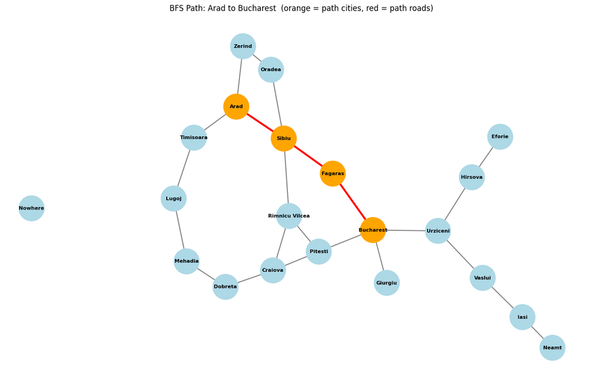

```python
bfs_path = bfs(G, 'Arad', 'Bucharest')
path_edges = [(bfs_path[i], bfs_path[i+1]) for i in range(len(bfs_path)-1)]

plt.figure(figsize=(13, 8))
pos = nx.spring_layout(G, seed=42)

node_colors = ['orange' if n in bfs_path else 'lightblue' for n in G.nodes()]

nx.draw(G, pos,
        with_labels=True,
        node_color=node_colors,
        node_size=1600,
        font_size=8,
        font_weight='bold',
        edge_color='gray',
        width=1.5)

nx.draw_networkx_edges(G, pos, edgelist=path_edges, edge_color='red', width=3)

plt.title('BFS Path: Arad to Bucharest  (orange = path cities, red = path roads)', fontsize=12)
plt.show()
```

## Short Explanation

|  | BFS | DFS |
| --- | --- | --- |
| Data Structure | Queue — `pop(0)` | Stack — `pop()` |
| Explores | Level by level | Deep first |
| Shortest path? | Yes | Not always |
| Returns | List of cities or None | List of cities or None |

The only real difference between BFS and DFS in the code is `pop(0)` vs `pop()`. Everything else is the same.